# Extended Split-ORFs analysis report

11 February 2021

This report shows a number of summary statistics of the a result files obtained from the Extended Split-ORFs Pipeline.

## DNA uniqueness

### Overview of the found unique DNA regions:

Number of Unique Regions: 10001  
Average length of unique region: 81  
Median length of unique region: 59  
Maximal length of unique region: 2533 (for region ENSG00000103723|ENST00000543938)

### This is the length distribution of the unique DNA regions

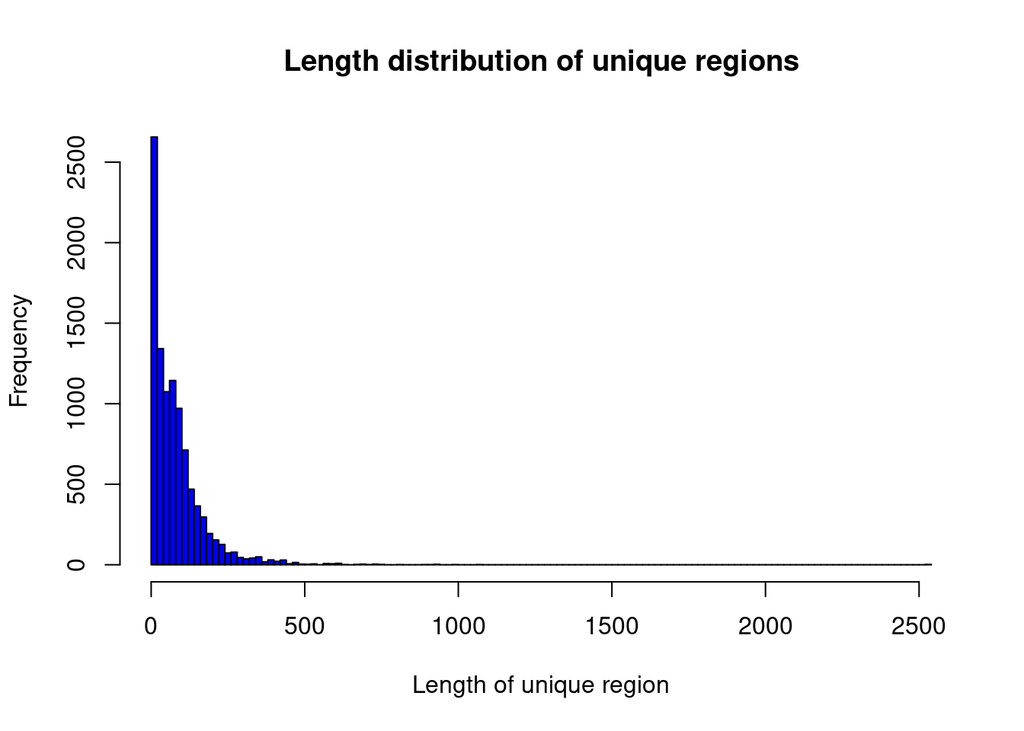

### This is the length distribution of the unique DNA regions corrected for the ambiguity of the MUMmer length parameter

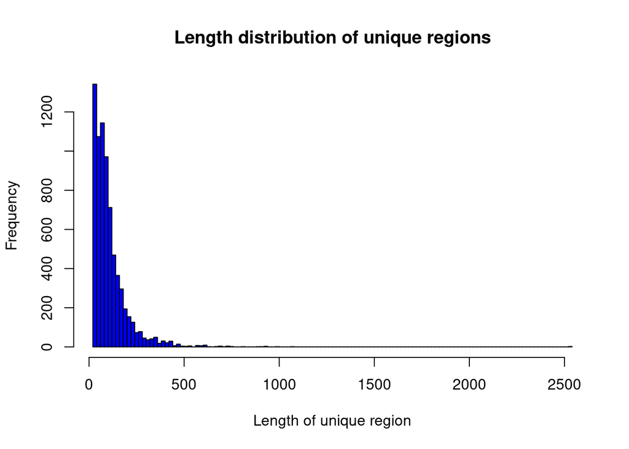

### This is the distribution of the unique DNA regions per transcript

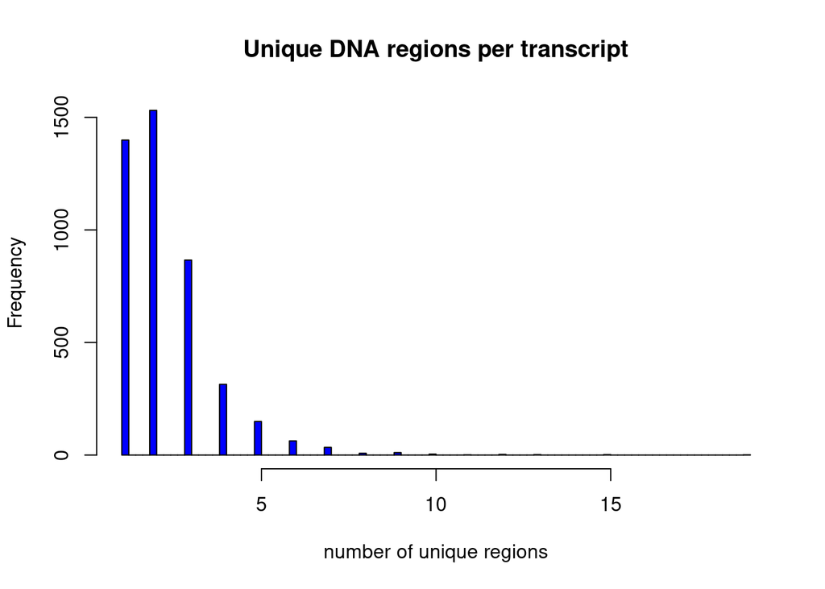

## Protein uniqueness

### Overview of the found unique Protein regions:

Number of Unique Regions: 9924  
Average length of unique region: 31  
Median length of unique region: 23  
Maximal length of unique region: 312 (for region ENSG00000115257|ENST00000441747:ORF-1630:640:1789:70-382)

### This is the length distribution of the unique protein regions

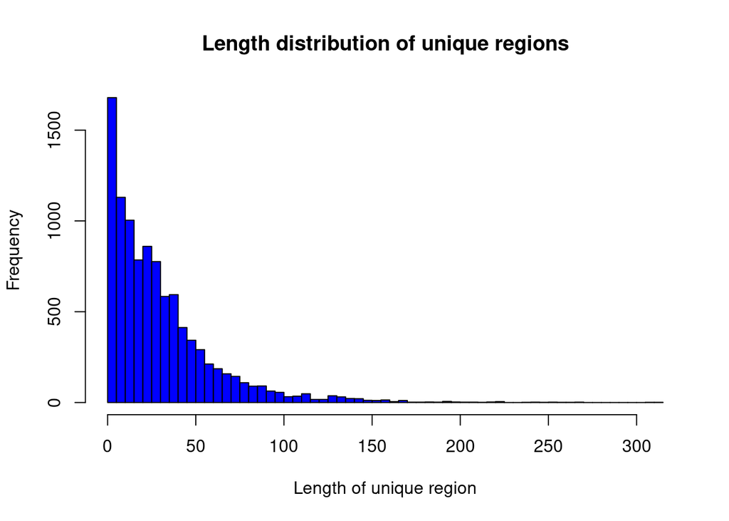

### This is the length distribution of the unique protein regions corrected for the ambiguity of the MUMmer length parameter

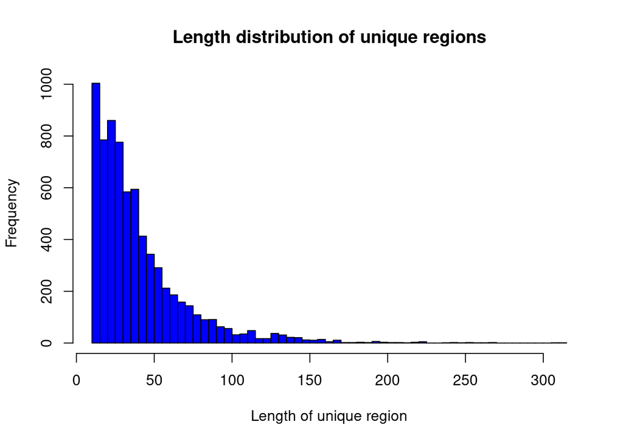

### This is the distribution of the unique Protein regions per transcript

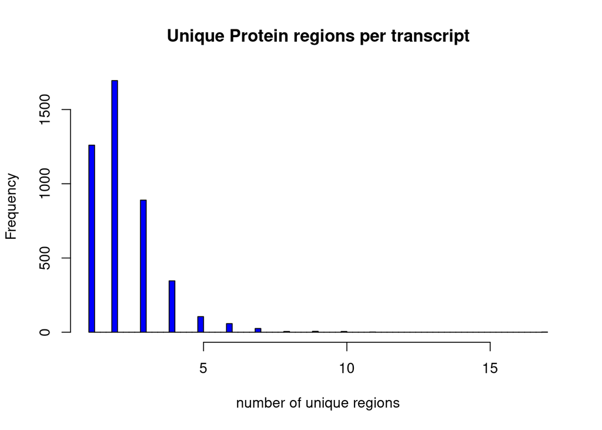

## Overall statistics

Number of transcripts with unique DNA region: 4388  
Number of transcripts with unique Protein region: 4397  
Number of transcripts with unique DNA and Protein region: 4257

This document was created with R Markdown and the Knit package. Markdown is a simple formatting syntax for authoring HTML, PDF, and MS Word documents. For more details on using R Markdown see http://rmarkdown.rstudio.com.